# Notebook 07 – Solutions

DSST289: Introduction to Data Science

Published

September 23, 2024

## Getting Started

Before running this notebook, select **Session > Restart R and Clear Output** in the menu above to start a new R session. This will clear any old data sets and give us a blank slate to start with.

After starting a new session, run the following code chunk to load the libraries and data that we will be working with today.

I have set the options `include=FALSE` and `message=FALSE` to avoid cluttering the solutions with all the output from this code.

## Practice

### DIY movie data

For this notebook, we will be creating a dataset, reading it into R, and producing a couple of different data visualizations.

We will create a dataset as a class describing movies that we have seen recently. Each student will be tasked with creating **five** rows of data. We will record data in the Google Sheets file linked to on Blackboard and [here](https://docs.google.com/spreadsheets/d/189QVmv5_2raf_ii-49UKnud4n3ITPmRcKOdHZzNs0G8/edit?usp=sharing).

### Data collection process

It is a good idea to collect data in a structured (and, ideally, reproducible) way. In the Google Sheet above, we’re going to collect the data in the columns as defined in the `dictionary` tab. Categorical variables (like genres) will be filled in using values from the `validation` tab.

The principle of selection for our observations is as follows:

Everyone will enter data for **five movies you remember seeing**. This could be a movie you saw last night, or it could be a memorable experience in childhood. Think of five memorable movie-watching experiences, and collect data about those movies.

Most information about our memorable movies will come directly from [IMDB](https://www.imdb.com/), but some will also capture our class’s tastes and preferences.

## `read_csv` movie data

Once you are finished with your entries, save the current version of the data set as a `.csv`.

In Google Sheets, do this by going to **File > Download > Comma Separated Values (.csv)**

This should download a file called `movies - data.csv` to your computer. The general pattern for Google Sheets is `filename - sheet.csv`, where `filename` is the name of the workbook in Google Sheets, and `sheet` is the name of the sheet that you *are viewing* when you download the `.csv`

Move that file to your `DSST289/data` directory.

Then, read it into R with the following block of code:

```r
movies <- read_csv("../data/movies - data.csv")

movies |>
  arrange(year) |>
  select(title, year, imdb_rating)
```

| title | year | imdb_rating |
| --- | --- | --- |
| It's a Wonderful Life | 1946 | 8.6 |
| Peter Pan | 1953 | 7.3 |
| Harakiki | 1962 | 8.6 |
| The Jungle Book | 1967 | 7.6 |
| Bedknobs and Broomsticks | 1971 | 7.0 |
| The Godfather | 1972 | 9.2 |
| Airplane! | 1980 | 7.7 |
| The Shining | 1980 | 8.4 |
| The Never Ending Story | 1984 | 7.3 |
| Little Shop of Horrors | 1986 | 7.1 |

[output cut: 206 more lines]

Then, produce a scatterplot below with the budget on the x-axis, gross worldwide earnings on the y-axis, points colored by the year of release, and the size of the points corresponding to contributors’ ratings. Use a text repel layer to label the movies by their title. Try using `scale_color_viridis_b()` to color the points in **bins** (hence `_b`). If you think it is needed, you may also include logarithmic scales for the x- and y-axes

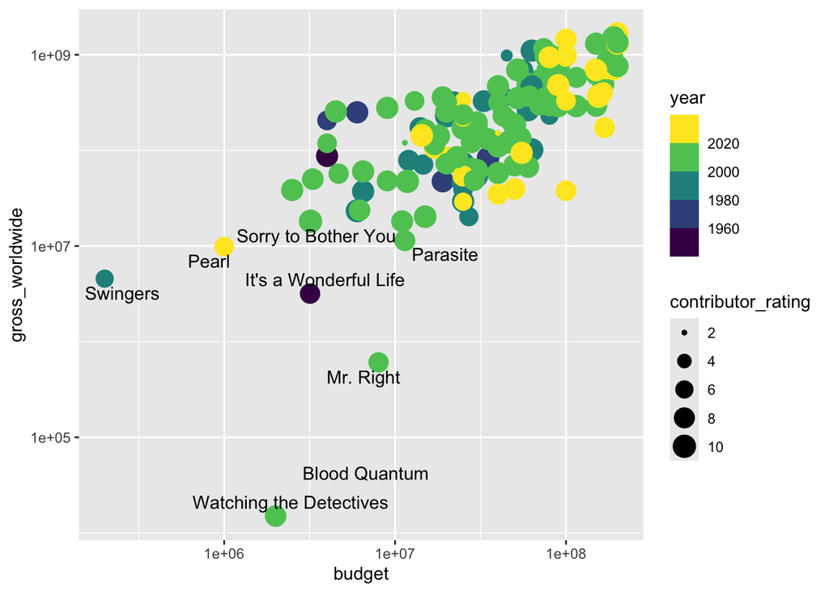

```r
movies |>
  # filter to retain only numeric values:
  filter(budget > 0 & gross_worldwide > 0) |>
  ggplot(aes(budget, gross_worldwide)) +
  geom_point(aes(color = year, size = contributor_rating)) +
  geom_text_repel(aes(label = title)) +
  scale_x_log10() +
  scale_y_log10() +
  scale_color_viridis_b()
```

### `mutate` review

Let’s use the data about the length of our films to create a new variable that describes the **total** length in minutes. This is the kind of thing `mutate` is great for:

```r
movies <- movies |>
  mutate(total_minutes = (runtime_hrs * 60) + runtime_min)

movies |>
  select(title, total_minutes) |>
  # we only want one row per title:
  distinct()
```

| title | total_minutes |
| --- | --- |
| Airplane! | 88 |
| It's a Wonderful Life | 130 |
| Peter Pan | 77 |
| Harakiki | 133 |
| Despicable Me | 95 |
| The Jungle Book | 78 |
| Bedknobs and Broomsticks | 117 |
| The Godfather | 175 |
| The Shining | 146 |
| The Never Ending Story | 102 |

[output cut: 147 more lines]

Now, let’s see if there appears to be any relationship between budget and length. Plot `budget` on the x-axis and `total_minutes` on y. As before, color points by `year`. Label the films and use viridis.

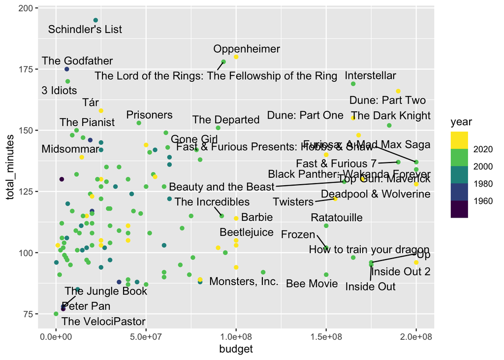

```r
movies |>
  select(title, budget, total_minutes, year) |>
  # ensure that we only have one point per title:
  distinct() |>
  ggplot(aes(budget, total_minutes)) +
  geom_point(aes(color = year)) +
  geom_text_repel(aes(label = title)) +
  scale_color_viridis_b()
```

### Class rating vs. IMDB rating

Let’s compare the ratings that we have given to the movies with IMDB ratings for the movies.

First, since there are probably going to be some overlapping movies, we might want to calculate the `mean` of our reviews for each movie. We also need the IMDB rating in the resulting table.

We can group our results by title, and summarize the `contributor_rating`s. All of the IMDB ratings *should* be the same, so we could use the `first()` summary function, which will take the first value in a column.[^1] Alternatively, we can also use `mean()`; the result should be the same if the data is entered properly.

We can also size the points based on the ratio of the `mean_class_rating` to the `imdb_rating`. If the class gave the film a higher review than IMDB, the value will be greater than 1. If the class gave the film a lower review than IMDB, the value will be less than 1.

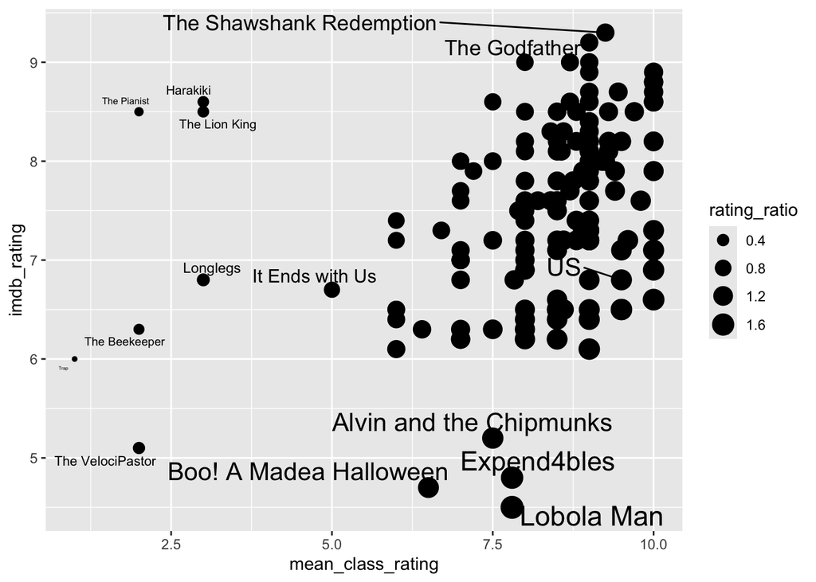

```r
movies |>
  group_by(title) |>
  summarize(
    mean_class_rating = mean(contributor_rating, na.rm = TRUE),
    # IMDB ratings should all be the same, but this works:
    imdb_rating = mean(imdb_rating, na.rm = TRUE)
  ) |>
  # filter out any missing or zero IMDB ratings to avoid dividing by zero:
  filter(!is.na(imdb_rating) & imdb_rating != 0) |>
  # calculate ratio:
  mutate(rating_ratio = mean_class_rating / imdb_rating) |>
  ggplot(aes(x = mean_class_rating, y = imdb_rating, size = rating_ratio)) +
  geom_point() +
  geom_text_repel(aes(label = title))
```

### Labels and Themes

For the last few questions, let’s finish a few loose ends about how to make data visualizations in R. The function `labs()` is an important element that can be added to any ggplot graphic. Inside the `labs()` function, you can set aesthetics from the plot equal to a string to change the corresponding label in the plot. For example, adding `labs(x = "HELLO!")` will change the label of the x-axis to the string “HELLO!” In the code below, take the previous code from above and add an appropriate label to the x-axis.

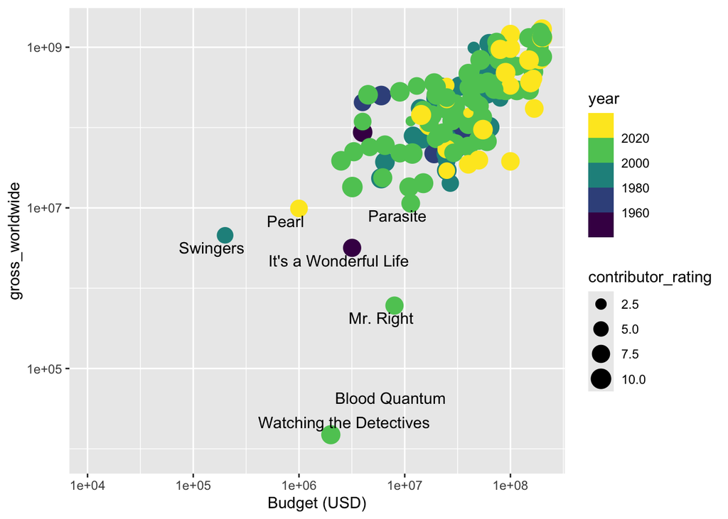

```r
movies |>
  ggplot(aes(budget, gross_worldwide)) +
  geom_point(aes(color = year, size = contributor_rating)) +
  geom_text_repel(aes(label = title)) +
  scale_x_log10() +
  scale_y_log10() +
  scale_color_viridis_b() +
  labs(x = "Budget (USD)")
```

Now, copy the code above and in the next block add appropriate labels for the y-axis, the color aesthetic, and the size aesthetic.

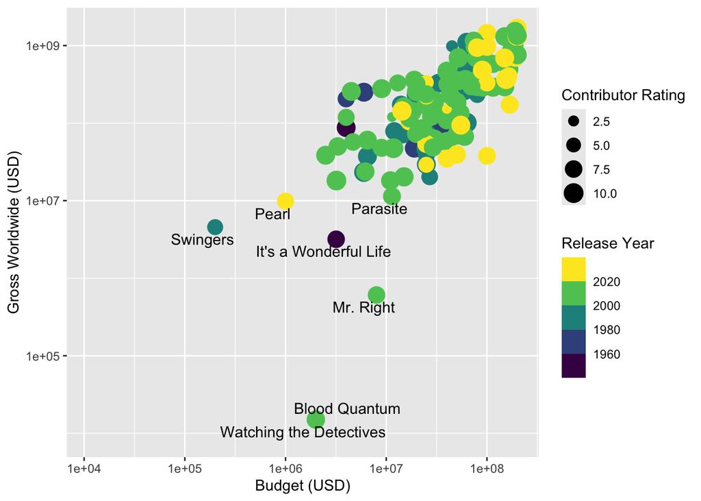

```r
movies |>
  ggplot(aes(budget, gross_worldwide)) +
  geom_point(aes(color = year, size = contributor_rating)) +
  geom_text_repel(aes(label = title)) +
  scale_x_log10() +
  scale_y_log10() +
  scale_color_viridis_b() +
  labs(
    x = "Budget (USD)", y = "Gross Worldwide (USD)",
    color = "Release Year", size = "Contributor Rating"
  )
```

There are three special additional elements that we can set inside of `labs()` called `title` (the main title of the plot), `subtitle`, and `caption` (the description at the bottom of the plot). Take the code above and add a title, subtitle, and caption.

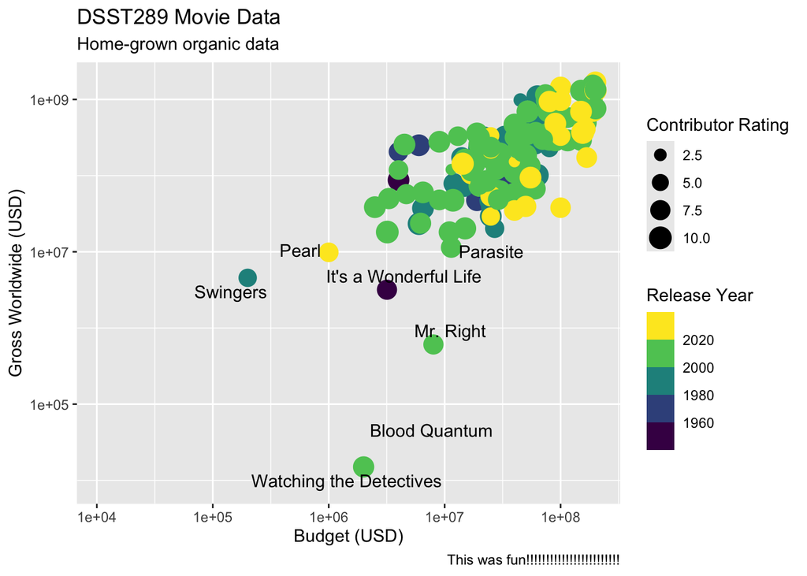

```r
movies |>
  ggplot(aes(budget, gross_worldwide)) +
  geom_point(aes(color = year, size = contributor_rating)) +
  geom_text_repel(aes(label = title)) +
  scale_x_log10() +
  scale_y_log10() +
  scale_color_viridis_b() +
  labs(
    x = "Budget (USD)", y = "Gross Worldwide (USD)",
    color = "Release Year", size = "Contributor Rating",
    title = "DSST289 Movie Data", subtitle = "Home-grown organic data",
    caption = "This was fun!!!!!!!!!!!!!!!!!!!!!!!!"
  )
```

In the plot below, copy your graphic from above and add one final element called `theme_tufte()`. This theme is named after [Edward Tufte](https://en.wikipedia.org/wiki/Edward_Tufte), who has been highly influential in data visualization. Among the many differences between his style and what we have seen so far, Tufte uses serif rather than sans-serif fonts in his graphics. We can change the font `family` used by default (Helvetica) to match this style with Times New Roman in `geom_text_repel()`. We can do the same by setting the `base_family` argument in `theme_tufte()` to `"Times New Roman"`.

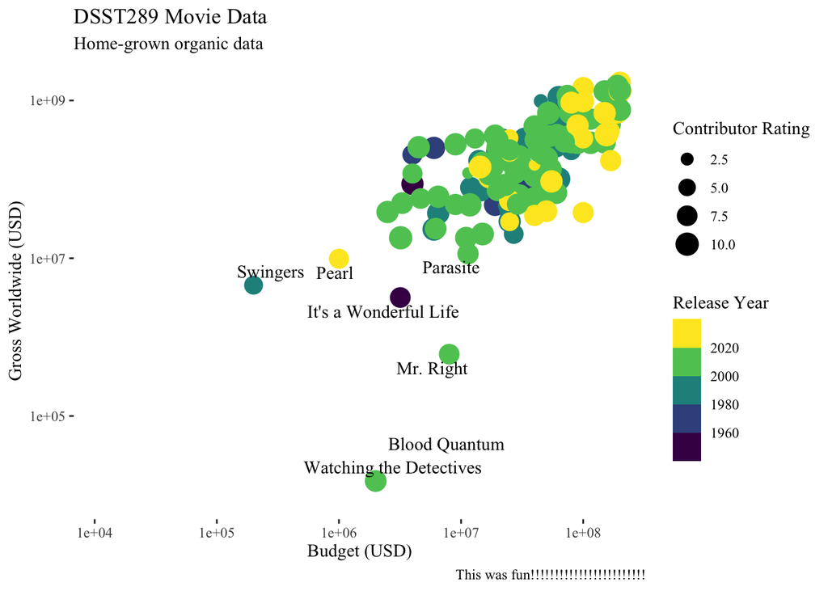

```r
movies |>
  ggplot(aes(budget, gross_worldwide)) +
  geom_point(aes(color = year, size = contributor_rating)) +
  # Note the addition of the `family` argument here:
  geom_text_repel(aes(label = title), family = "Times New Roman") +
  scale_x_log10() +
  scale_y_log10() +
  scale_color_viridis_b() +
  labs(
    x = "Budget (USD)", y = "Gross Worldwide (USD)",
    color = "Release Year", size = "Contributor Rating",
    title = "DSST289 Movie Data", subtitle = "Home-grown organic data",
    caption = "This was fun!!!!!!!!!!!!!!!!!!!!!!!!"
  ) +
  # Note this:
  theme_tufte(base_family = "Times New Roman")
```

I like this theme a lot for creating graphics for publication because it is very clean and avoids using extra ink that I can make better use of with manual annotations. There are other themes that you can read about in the R documentation to change the way a `ggplot` object looks. Several other R packages also provide additional themes ready to use out of the box.

## Footnotes

[^1]: If we are not certain that our data is perfect, this may not be the best choice! It would be smarter to check and see that all values in the `imdb_rating` column are the same before taking the `first()`.